# 2021 NSDUH Preliminary Analysis: NC, South, and U.S.

Auten Lunsford

# Introduction

The following is an analysis of preliminary prevalence estimates from the 2021 National Survey on Drug Use and Health (NSDUH). In particular, the prevalence estimates for the populations of North Carolina (NC), the Southern Region of the United States (South), and the total United States (U.S.) were compared to reveal statistically significant differences among corresponding age groups.  
The South includes the following states: Delaware, District of Columbia, Florida, Georgia, Maryland, North Carolina, South Carolina, Virginia, West Virginia, Alabama, Kentucky, Mississippi, Tennessee, Arkansas, Louisiana, Oklahoma, and Texas.

# Disclaimer

The data analyzed in this project were preliminary prevalence estimates provided by the Substance Abuse and Mental Health Services Administration (SAMHSA), which are no longer available on their website. Thus, there may be discrepancies between the data seen here and that published in the updated, comprehensive 2021 NSDUH. Please refer to the cited source below for the most updated and accurate information:  
Center for Behavioral Health Statistics and Quality. (2022). *Results from the 2021 National Survey on Drug Use and Health: Detailed tables*. Substance Abuse and Mental Health Services Administration. https://www.samhsa.gov/data/report/2021-nsduh-detailed-tables

# Methodology

State and census region estimates, along with the 95 percent Bayesian confidence (credible) intervals, are based on a survey-weighted hierarchical Bayes small area estimation approach and generated by Markov Chain Monte Carlo techniques. For the U.S. estimates, design-based (direct) estimates and corresponding 95 percent confidence intervals are given.  
Thirty five tables were cleaned and analyzed to reveal statistically significant differences in prevalence estimates between the populations of NC, the South, and the U.S, among corresponding age groups (12 - 17, 18 - 25, and 26+). Prevalence estimates were deemed significantly different if their 95% confidence intervals did not overlap. The three regions were only compared among corresponding age groups (e.g. NC: 18 - 25 was not compared with South: 12 - 17), and age groups were not compared within a single region.  
Tables 1 - 16, 18 - 28, and 32 listed prevalence estimates among people aged 12 or older. Tables 29 - 31 and 33 - 35 listed prevalence estimates among people aged 18 or older. Table 17 only lists prevalence estimates for one age group (people aged 12-20).

## Setup

```r
# Downloading required packages
library(readr)
library(tidyverse)
library(knitr)

# Ensuring that the code is included in the output document
opts_chunk$set(echo = TRUE)
```

```r
# Pre-allocating a list to hold any table numbers whose tables contained significant differences
significance_list <- numeric(35)

# Columns and tables used for reshaping data
state = c("Total U.S.", "Total U.S.", "Total U.S.", "South", "South", "South", "North Carolina", "North Carolina", "North Carolina")
state_2 = c("Total U.S.", "Total U.S.", "South", "South", "North Carolina", "North Carolina")

age_group = c("12-17", "18-25", "26+", "12-17", "18-25", "26+", "12-17", "18-25", "26+")
table_17_group = c("Alcohol Use", "Binge Alcohol Use", "Alcohol Use", "Binge Alcohol Use", "Alcohol Use", "Binge Alcohol Use")

table_reshape <- data.frame(state, age_group)
table_17_reshape <- data.frame(state_2, table_17_group)
colnames(table_17_reshape)[1] <- "state"
```

## Cleaning and Analysis

```r
# Table numbers that the following for loop operates on
table_nums = c(1:16, 18:28, 32)

# Iterating through every table mentioned above
for (n in table_nums) {

  # Reading raw data
  table_data <- read.csv(sprintf('NSDUHsaeExcelTab%02d-2021.csv', n))

  # Cleaning data
  num_empty_rows = which(table_data$X == "State") - 1
  table_data <- table_data[-(1:num_empty_rows), -c(1, 3:5, 15:17)]
  colnames(table_data) <- as.character(table_data[1, ])
  table_data <- table_data[-1, ] %>%
    filter(State == "Total U.S." | State == "South" | State == "North Carolina")

  for (r in 1:3) {
    table_data[r, -1] <- sub("%", "", table_data[r, -1])
  }
  table_data[ , -1] <- lapply(table_data[ , -1], as.numeric)

  # Building results table
  comparison = c("U.S. > South", "U.S. < South", "U.S. > NC", "U.S. < NC", "South > NC", "South < NC")
  results_table = data.frame(comparison, col2 = logical(length(comparison)), col3 = logical(length(comparison)), col4 = logical(length(comparison)))
  colnames(results_table)[2] <- "12-17"
  colnames(results_table)[3] <- "18-25"
  colnames(results_table)[4] <- "26+"

  results_table[1, -1] <- table_data[1, c(3, 6, 9)] > table_data[2, c(4, 7, 10)]
  results_table[2, -1] <- table_data[1, c(4, 7, 10)] < table_data[2, c(3, 6, 9)]
  results_table[3, -1] <- table_data[1, c(3, 6, 9)] > table_data[3, c(4, 7, 10)]
  results_table[4, -1] <- table_data[1, c(4, 7, 10)] < table_data[3, c(3, 6, 9)]
  results_table[5, -1] <- table_data[2, c(3, 6, 9)] > table_data[3, c(4, 7, 10)]
  results_table[6, -1] <- table_data[2, c(4, 7, 10)] < table_data[3, c(3, 6, 9)]

  print(kable(results_table, caption = sprintf("Table %d", n)))

  # Storing tables with significant differences among U.S., South, or NC
  if (TRUE %in% results_table[ , 2] | TRUE %in% results_table[ , 3] |
      TRUE %in% results_table[ , 4]) {
    significance_list[n] <- n

    # Creating list of specific significance indicators for age groups and regions (to be used in reshaped data)
    significant_difference = numeric(9)
    for (col in c(2:4)) {
      if (results_table[1, col] == TRUE | results_table[2, col] == TRUE) {
        significant_difference[col - 1] <- 1
        significant_difference[col + 2] <- 1
      }
      if (results_table[3, col] == TRUE | results_table[4, col] == TRUE) {
        significant_difference[col - 1] <- 1
        significant_difference[col + 5] <- 1
      }
      if (results_table[5, col] == TRUE | results_table[6, col] == TRUE) {
        significant_difference[col + 2] <- 1
        significant_difference[col + 5] <- 1
      }
    }

    # Reshaping data
    table_reshape$estimate[1:3] <- t(table_data[1, c(2, 5, 8)])
    table_reshape$estimate[4:6] <- t(table_data[2, c(2, 5, 8)])
    table_reshape$estimate[7:9] <- t(table_data[3, c(2, 5, 8)])

    table_reshape$lower_CI[1:3] <- t(table_data[1, c(3, 6, 9)])
    table_reshape$lower_CI[4:6] <- t(table_data[2, c(3, 6, 9)])
    table_reshape$lower_CI[7:9] <- t(table_data[3, c(3, 6, 9)])

    table_reshape$upper_CI[1:3] <- t(table_data[1, c(4, 7, 10)])
    table_reshape$upper_CI[4:6] <- t(table_data[2, c(4, 7, 10)])
    table_reshape$upper_CI[7:9] <- t(table_data[3, c(4, 7, 10)])

    table_reshape$significant_diff <- significant_difference

    assign(sprintf('table_%d', n), table_reshape)
  }
}
```

Table 1

| comparison | 12-17 | 18-25 | 26+ |
| --- | --- | --- | --- |
| U.S. > South | FALSE | TRUE | TRUE |
| U.S. < South | FALSE | FALSE | FALSE |
| U.S. > NC | FALSE | TRUE | FALSE |
| U.S. < NC | FALSE | FALSE | FALSE |
| South > NC | FALSE | FALSE | FALSE |
| South < NC | FALSE | FALSE | FALSE |

Table 2

| comparison | 12-17 | 18-25 | 26+ |
| --- | --- | --- | --- |
| U.S. > South | FALSE | TRUE | TRUE |
| U.S. < South | FALSE | FALSE | FALSE |
| U.S. > NC | FALSE | TRUE | TRUE |
| U.S. < NC | FALSE | FALSE | FALSE |
| South > NC | FALSE | FALSE | FALSE |
| South < NC | FALSE | FALSE | FALSE |

Table 3

| comparison | 12-17 | 18-25 | 26+ |
| --- | --- | --- | --- |
| U.S. > South | FALSE | TRUE | TRUE |
| U.S. < South | FALSE | FALSE | FALSE |
| U.S. > NC | FALSE | FALSE | FALSE |
| U.S. < NC | FALSE | FALSE | FALSE |
| South > NC | FALSE | FALSE | FALSE |
| South < NC | FALSE | FALSE | FALSE |

Table 4

| comparison | 12-17 | 18-25 | 26+ |
| --- | --- | --- | --- |
| U.S. > South | FALSE | FALSE | FALSE |
| U.S. < South | TRUE | FALSE | TRUE |
| U.S. > NC | FALSE | FALSE | FALSE |
| U.S. < NC | FALSE | FALSE | FALSE |
| South > NC | FALSE | FALSE | FALSE |
| South < NC | FALSE | FALSE | FALSE |

Table 5

| comparison | 12-17 | 18-25 | 26+ |
| --- | --- | --- | --- |
| U.S. > South | FALSE | FALSE | FALSE |
| U.S. < South | FALSE | FALSE | FALSE |
| U.S. > NC | FALSE | FALSE | FALSE |
| U.S. < NC | FALSE | FALSE | FALSE |
| South > NC | FALSE | FALSE | FALSE |
| South < NC | FALSE | FALSE | FALSE |

Table 6

| comparison | 12-17 | 18-25 | 26+ |
| --- | --- | --- | --- |
| U.S. > South | FALSE | FALSE | FALSE |
| U.S. < South | FALSE | FALSE | FALSE |
| U.S. > NC | FALSE | FALSE | FALSE |
| U.S. < NC | FALSE | FALSE | FALSE |
| South > NC | FALSE | FALSE | FALSE |
| South < NC | FALSE | FALSE | FALSE |

Table 7

| comparison | 12-17 | 18-25 | 26+ |
| --- | --- | --- | --- |
| U.S. > South | FALSE | FALSE | FALSE |
| U.S. < South | FALSE | FALSE | FALSE |
| U.S. > NC | FALSE | FALSE | FALSE |
| U.S. < NC | FALSE | FALSE | FALSE |
| South > NC | FALSE | FALSE | FALSE |
| South < NC | FALSE | FALSE | FALSE |

Table 8

| comparison | 12-17 | 18-25 | 26+ |
| --- | --- | --- | --- |
| U.S. > South | FALSE | FALSE | FALSE |
| U.S. < South | FALSE | FALSE | TRUE |
| U.S. > NC | FALSE | FALSE | FALSE |
| U.S. < NC | FALSE | FALSE | FALSE |
| South > NC | FALSE | FALSE | FALSE |
| South < NC | FALSE | FALSE | FALSE |

Table 9

| comparison | 12-17 | 18-25 | 26+ |
| --- | --- | --- | --- |
| U.S. > South | NA | FALSE | FALSE |
| U.S. < South | NA | FALSE | FALSE |
| U.S. > NC | NA | FALSE | FALSE |
| U.S. < NC | NA | FALSE | FALSE |
| South > NC | NA | FALSE | FALSE |
| South < NC | NA | FALSE | FALSE |

Table 10

| comparison | 12-17 | 18-25 | 26+ |
| --- | --- | --- | --- |
| U.S. > South | FALSE | FALSE | FALSE |
| U.S. < South | FALSE | FALSE | TRUE |
| U.S. > NC | FALSE | FALSE | FALSE |
| U.S. < NC | FALSE | FALSE | FALSE |
| South > NC | FALSE | FALSE | FALSE |
| South < NC | FALSE | FALSE | FALSE |

Table 11

| comparison | 12-17 | 18-25 | 26+ |
| --- | --- | --- | --- |
| U.S. > South | FALSE | FALSE | FALSE |
| U.S. < South | FALSE | FALSE | FALSE |
| U.S. > NC | FALSE | FALSE | FALSE |
| U.S. < NC | FALSE | FALSE | FALSE |
| South > NC | FALSE | FALSE | FALSE |
| South < NC | FALSE | FALSE | FALSE |

Table 12

| comparison | 12-17 | 18-25 | 26+ |
| --- | --- | --- | --- |
| U.S. > South | FALSE | FALSE | FALSE |
| U.S. < South | FALSE | FALSE | FALSE |
| U.S. > NC | FALSE | FALSE | FALSE |
| U.S. < NC | FALSE | FALSE | FALSE |
| South > NC | FALSE | FALSE | FALSE |
| South < NC | FALSE | FALSE | FALSE |

Table 13

| comparison | 12-17 | 18-25 | 26+ |
| --- | --- | --- | --- |
| U.S. > South | FALSE | FALSE | FALSE |
| U.S. < South | FALSE | FALSE | FALSE |
| U.S. > NC | FALSE | FALSE | FALSE |
| U.S. < NC | FALSE | FALSE | FALSE |
| South > NC | FALSE | FALSE | FALSE |
| South < NC | FALSE | FALSE | FALSE |

Table 14

| comparison | 12-17 | 18-25 | 26+ |
| --- | --- | --- | --- |
| U.S. > South | FALSE | FALSE | FALSE |
| U.S. < South | FALSE | FALSE | FALSE |
| U.S. > NC | FALSE | FALSE | FALSE |
| U.S. < NC | FALSE | FALSE | FALSE |
| South > NC | FALSE | FALSE | FALSE |
| South < NC | FALSE | FALSE | FALSE |

Table 15

| comparison | 12-17 | 18-25 | 26+ |
| --- | --- | --- | --- |
| U.S. > South | FALSE | FALSE | FALSE |
| U.S. < South | FALSE | FALSE | FALSE |
| U.S. > NC | FALSE | FALSE | FALSE |
| U.S. < NC | FALSE | FALSE | FALSE |
| South > NC | FALSE | FALSE | FALSE |
| South < NC | FALSE | FALSE | FALSE |

Table 16

| comparison | 12-17 | 18-25 | 26+ |
| --- | --- | --- | --- |
| U.S. > South | FALSE | FALSE | FALSE |
| U.S. < South | FALSE | FALSE | FALSE |
| U.S. > NC | FALSE | FALSE | FALSE |
| U.S. < NC | FALSE | FALSE | FALSE |
| South > NC | FALSE | FALSE | FALSE |
| South < NC | FALSE | FALSE | FALSE |

Table 18

| comparison | 12-17 | 18-25 | 26+ |
| --- | --- | --- | --- |
| U.S. > South | FALSE | FALSE | FALSE |
| U.S. < South | FALSE | FALSE | TRUE |
| U.S. > NC | FALSE | FALSE | FALSE |
| U.S. < NC | FALSE | FALSE | FALSE |
| South > NC | FALSE | FALSE | FALSE |
| South < NC | FALSE | FALSE | FALSE |

Table 19

| comparison | 12-17 | 18-25 | 26+ |
| --- | --- | --- | --- |
| U.S. > South | FALSE | FALSE | FALSE |
| U.S. < South | FALSE | FALSE | FALSE |
| U.S. > NC | FALSE | FALSE | FALSE |
| U.S. < NC | FALSE | FALSE | FALSE |
| South > NC | FALSE | FALSE | FALSE |
| South < NC | FALSE | FALSE | FALSE |

Table 20

| comparison | 12-17 | 18-25 | 26+ |
| --- | --- | --- | --- |
| U.S. > South | FALSE | FALSE | FALSE |
| U.S. < South | FALSE | FALSE | FALSE |
| U.S. > NC | FALSE | FALSE | FALSE |
| U.S. < NC | FALSE | FALSE | FALSE |
| South > NC | FALSE | FALSE | FALSE |
| South < NC | FALSE | FALSE | FALSE |

Table 21

| comparison | 12-17 | 18-25 | 26+ |
| --- | --- | --- | --- |
| U.S. > South | FALSE | FALSE | FALSE |
| U.S. < South | FALSE | FALSE | FALSE |
| U.S. > NC | FALSE | FALSE | FALSE |
| U.S. < NC | FALSE | FALSE | FALSE |
| South > NC | FALSE | FALSE | FALSE |
| South < NC | FALSE | FALSE | FALSE |

Table 22

| comparison | 12-17 | 18-25 | 26+ |
| --- | --- | --- | --- |
| U.S. > South | FALSE | FALSE | FALSE |
| U.S. < South | FALSE | FALSE | FALSE |
| U.S. > NC | FALSE | FALSE | FALSE |
| U.S. < NC | FALSE | FALSE | FALSE |
| South > NC | FALSE | FALSE | FALSE |
| South < NC | FALSE | FALSE | FALSE |

Table 23

| comparison | 12-17 | 18-25 | 26+ |
| --- | --- | --- | --- |
| U.S. > South | FALSE | FALSE | FALSE |
| U.S. < South | FALSE | FALSE | FALSE |
| U.S. > NC | FALSE | FALSE | FALSE |
| U.S. < NC | FALSE | FALSE | FALSE |
| South > NC | FALSE | FALSE | FALSE |
| South < NC | FALSE | FALSE | FALSE |

Table 24

| comparison | 12-17 | 18-25 | 26+ |
| --- | --- | --- | --- |
| U.S. > South | FALSE | FALSE | FALSE |
| U.S. < South | FALSE | FALSE | FALSE |
| U.S. > NC | FALSE | FALSE | FALSE |
| U.S. < NC | FALSE | FALSE | FALSE |
| South > NC | FALSE | FALSE | FALSE |
| South < NC | FALSE | FALSE | FALSE |

Table 25

| comparison | 12-17 | 18-25 | 26+ |
| --- | --- | --- | --- |
| U.S. > South | FALSE | FALSE | FALSE |
| U.S. < South | FALSE | FALSE | FALSE |
| U.S. > NC | FALSE | FALSE | FALSE |
| U.S. < NC | FALSE | FALSE | FALSE |
| South > NC | FALSE | FALSE | FALSE |
| South < NC | FALSE | FALSE | FALSE |

Table 26

| comparison | 12-17 | 18-25 | 26+ |
| --- | --- | --- | --- |
| U.S. > South | FALSE | FALSE | FALSE |
| U.S. < South | FALSE | FALSE | FALSE |
| U.S. > NC | FALSE | FALSE | FALSE |
| U.S. < NC | FALSE | FALSE | FALSE |
| South > NC | FALSE | FALSE | FALSE |
| South < NC | FALSE | FALSE | FALSE |

Table 27

| comparison | 12-17 | 18-25 | 26+ |
| --- | --- | --- | --- |
| U.S. > South | FALSE | FALSE | FALSE |
| U.S. < South | FALSE | FALSE | FALSE |
| U.S. > NC | FALSE | FALSE | FALSE |
| U.S. < NC | FALSE | FALSE | FALSE |
| South > NC | FALSE | FALSE | FALSE |
| South < NC | FALSE | FALSE | FALSE |

Table 28

| comparison | 12-17 | 18-25 | 26+ |
| --- | --- | --- | --- |
| U.S. > South | FALSE | FALSE | FALSE |
| U.S. < South | FALSE | FALSE | FALSE |
| U.S. > NC | FALSE | FALSE | FALSE |
| U.S. < NC | FALSE | FALSE | FALSE |
| South > NC | FALSE | FALSE | FALSE |
| South < NC | FALSE | FALSE | FALSE |

Table 32

| comparison | 12-17 | 18-25 | 26+ |
| --- | --- | --- | --- |
| U.S. > South | FALSE | FALSE | FALSE |
| U.S. < South | FALSE | FALSE | FALSE |
| U.S. > NC | FALSE | FALSE | FALSE |
| U.S. < NC | FALSE | FALSE | FALSE |
| South > NC | FALSE | FALSE | FALSE |
| South < NC | FALSE | FALSE | FALSE |

```r
# Printing table numbers so far that contained significant differences
kable(t(significance_list[significance_list != 0]), caption = "Table numbers containing significant differences")
```

Table numbers containing significant differences

| 1 | 2 | 3 | 4 | 8 | 10 | 18 |
| --- | --- | --- | --- | --- | --- | --- |

```r
# Table Numbers that this for loop operates on
table_nums = c(17, 29:31, 33:35)

# Iterating through every table mentioned above
for (n in table_nums) {

  # Reading raw data
  table_data <- read.csv(sprintf('NSDUHsaeExcelTab%02d-2021.csv', n))

  # Cleaning data
  num_empty_rows = which(table_data$X == "State") - 1
  if (n == 17) {
    table_data <- table_data[-(1:num_empty_rows), -1]
  } else {
    table_data <- table_data[-(1:num_empty_rows), -c(1, 3:5)]
  }

  colnames(table_data) <- as.character(table_data[1, ])
  table_data <- table_data[-1, ] %>%
    filter(State == "Total U.S." | State == "South" | State == "North Carolina")

  for (r in 1:3) {
    table_data[r, -1] <- sub("%", "", table_data[r, -1])
  }
  table_data[ , -1] <- lapply(table_data[ , -1], as.numeric)

  # Building results table
  comparison = c("U.S. > South", "U.S. < South", "U.S. > NC", "U.S. < NC", "South > NC", "South < NC")
  results_table = data.frame(comparison, col2 = logical(length(comparison)), col3 = logical(length(comparison)))
  if (n == 17) {
    colnames(results_table)[2] <- "Alcohol Use in Past Month"
    colnames(results_table)[3] <- "Binge Alcohol Use in Past Month"
  } else {
    colnames(results_table)[2] <- "18-25"
    colnames(results_table)[3] <- "26+"
  }

  results_table[1, -1] <- table_data[1, c(3, 6)] > table_data[2, c(4, 7)]
  results_table[2, -1] <- table_data[1, c(4, 7)] < table_data[2, c(3, 6)]
  results_table[3, -1] <- table_data[1, c(3, 6)] > table_data[3, c(4, 7)]
  results_table[4, -1] <- table_data[1, c(4, 7)] < table_data[3, c(3, 6)]
  results_table[5, -1] <- table_data[2, c(3, 6)] > table_data[3, c(4, 7)]
  results_table[6, -1] <- table_data[2, c(4, 7)] < table_data[3, c(3, 6)]

  print(kable(results_table, caption = sprintf("Table %d", n)))

  # Storing tables with significant differences among U.S., South, or NC
  if (TRUE %in% results_table[ , 2] | TRUE %in% results_table[ , 3]) {
    significance_list[n] <- n

    # Creating list of specific significance indicators for groups and regions (to be used in reshaped data)
    significant_difference = numeric(6)
    for (col in c(2:3)) {
      if (results_table[1, col] == TRUE | results_table[2, col] == TRUE) {
        significant_difference[col - 1] <- 1
        significant_difference[col + 1] <- 1
      }
      if (results_table[3, col] == TRUE | results_table[4, col] == TRUE) {
        significant_difference[col - 1] <- 1
        significant_difference[col + 3] <- 1
      }
      if (results_table[5, col] == TRUE | results_table[6, col] == TRUE) {
        significant_difference[col + 1] <- 1
        significant_difference[col + 3] <- 1
      }
    }

    # (Table 17 is the only table with significant differences, so it is the only one that undergoes reshaping)
    if (n == 17) {
      table_17 <- table_17_reshape

      table_17$estimate[1:2] <- t(table_data[1, c(2, 5)])
      table_17$estimate[3:4] <- t(table_data[2, c(2, 5)])
      table_17$estimate[5:6] <- t(table_data[3, c(2, 5)])

      table_17$lower_CI[1:2] <- t(table_data[1, c(3, 6)])
      table_17$lower_CI[3:4] <- t(table_data[2, c(3, 6)])
      table_17$lower_CI[5:6] <- t(table_data[3, c(3, 6)])

      table_17$upper_CI[1:2] <- t(table_data[1, c(4, 7)])
      table_17$upper_CI[3:4] <- t(table_data[2, c(4, 7)])
      table_17$upper_CI[5:6] <- t(table_data[3, c(4, 7)])

      table_17$significant_diff <- significant_difference
    }

  }
}
```

Table 17

| comparison | Alcohol Use in Past Month | Binge Alcohol Use in Past Month |
| --- | --- | --- |
| U.S. > South | FALSE | FALSE |
| U.S. < South | FALSE | FALSE |
| U.S. > NC | TRUE | FALSE |
| U.S. < NC | FALSE | FALSE |
| South > NC | FALSE | FALSE |
| South < NC | FALSE | FALSE |

Table 29

| comparison | 18-25 | 26+ |
| --- | --- | --- |
| U.S. > South | FALSE | FALSE |
| U.S. < South | FALSE | FALSE |
| U.S. > NC | FALSE | FALSE |
| U.S. < NC | FALSE | FALSE |
| South > NC | FALSE | FALSE |
| South < NC | FALSE | FALSE |

Table 30

| comparison | 18-25 | 26+ |
| --- | --- | --- |
| U.S. > South | FALSE | FALSE |
| U.S. < South | FALSE | FALSE |
| U.S. > NC | FALSE | FALSE |
| U.S. < NC | FALSE | FALSE |
| South > NC | FALSE | FALSE |
| South < NC | FALSE | FALSE |

Table 31

| comparison | 18-25 | 26+ |
| --- | --- | --- |
| U.S. > South | FALSE | FALSE |
| U.S. < South | FALSE | FALSE |
| U.S. > NC | FALSE | FALSE |
| U.S. < NC | FALSE | FALSE |
| South > NC | FALSE | FALSE |
| South < NC | FALSE | FALSE |

Table 33

| comparison | 18-25 | 26+ |
| --- | --- | --- |
| U.S. > South | FALSE | FALSE |
| U.S. < South | FALSE | FALSE |
| U.S. > NC | FALSE | FALSE |
| U.S. < NC | FALSE | FALSE |
| South > NC | FALSE | FALSE |
| South < NC | FALSE | FALSE |

Table 34

| comparison | 18-25 | 26+ |
| --- | --- | --- |
| U.S. > South | FALSE | FALSE |
| U.S. < South | FALSE | FALSE |
| U.S. > NC | FALSE | FALSE |
| U.S. < NC | FALSE | FALSE |
| South > NC | FALSE | FALSE |
| South < NC | FALSE | FALSE |

Table 35

| comparison | 18-25 | 26+ |
| --- | --- | --- |
| U.S. > South | FALSE | FALSE |
| U.S. < South | FALSE | FALSE |
| U.S. > NC | FALSE | FALSE |
| U.S. < NC | FALSE | FALSE |
| South > NC | FALSE | FALSE |
| South < NC | FALSE | FALSE |

```r
# Printing table numbers that contained significant differences
kable(t(significance_list[significance_list != 0]), caption = "Table numbers containing significant differences")
```

Table numbers containing significant differences

| 1 | 2 | 3 | 4 | 8 | 10 | 17 | 18 |
| --- | --- | --- | --- | --- | --- | --- | --- |

# Results

The following figures display significant differences found among the prevalence estimates in Tables 1 - 4, 8, 10, 17, and 18. The y axis in the bar charts records the estimated percentage of the population that either:  
1) has used that substance in the given time frame (upon responding to the survey), or  
2) perceives a great risk from using that substance at a given frequency  
The confidence intervals for these estimates are listed alongside the bar charts.

```r
# Constants used in plotting and tables
label_nudge = 0.45
error_bar_width = 0.4

col_names = c("State", "Lower CI", "Upper CI")
```

### Table 1 Results (among people aged 12 or older)

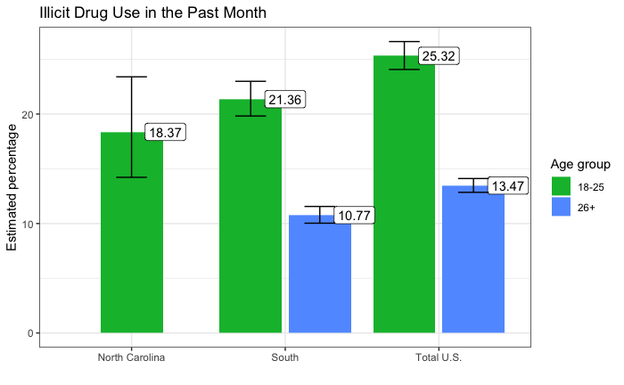

```r
# Selecting prevalence estimates that were significantly different from another
significant_data = subset(table_1, significant_diff == "1")

# Creating bar chart
ggplot(data = significant_data,
       mapping = aes(x = state, y = estimate, label = estimate, group = age_group)) +

  ggtitle("Illicit Drug Use in the Past Month") +

  ylab("Estimated percentage") +
  xlab("") +

  guides(fill = guide_legend(title = "Age group")) +

  geom_bar(aes(fill = age_group),
           stat = "identity",
           position = position_dodge2(preserve = "single")) +

  geom_label(data = subset(significant_data, state == "North Carolina"),
             nudge_x = label_nudge * (0.22 / 0.45)) +
  geom_label(data = subset(significant_data, age_group == "18-25" & state != "North Carolina")) +
  geom_label(data = subset(significant_data, age_group == "26+"),
             nudge_x = label_nudge) +

  geom_errorbar(data = subset(significant_data, state != "North Carolina"),
                aes(ymin = lower_CI, ymax = upper_CI),
                position = position_dodge(preserve = "single", width = 0.9),
                width = error_bar_width) +

  geom_errorbar(data = subset(significant_data, state == "North Carolina"),
                aes(ymin = lower_CI, ymax = upper_CI),
                width = 0.5 * error_bar_width) +

  scale_fill_manual(values = c("#00BA38","#619CFF")) +

  theme_bw()
```

```r
# Creating tables of confidence intervals
kable(subset(significant_data, age_group == "18-25")[ , -c(2, 3, 6)],
      caption = "Confidence intervals for Table 1 (18 - 25 years old)",
      row.names = FALSE,
      col.names = col_names)
```

Confidence intervals for Table 1 (18 - 25 years old)

| State | Lower CI | Upper CI |
| --- | --- | --- |
| Total U.S. | 24.07 | 26.62 |
| South | 19.82 | 22.99 |
| North Carolina | 14.22 | 23.40 |

```r
kable(subset(significant_data, age_group == "26+")[ , -c(2, 3, 6)],
      caption = "Confidence intervals for Table 1 (26+ years old)",
      row.names = FALSE,
      col.names = col_names)
```

Confidence intervals for Table 1 (26+ years old)

| State | Lower CI | Upper CI |
| --- | --- | --- |
| Total U.S. | 12.85 | 14.11 |
| South | 10.03 | 11.56 |

Illicit drug use includes the misuse of prescription psychotherapeutics or the use of marijuana (including vaping), cocaine (including crack), heroin, hallucinogens, inhalants, or methamphetamine. Misuse of prescription psychotherapeutics is defined as use in any way not directed by a doctor, including use without a prescription of one’s own; use in greater amounts, more often, or longer than told; or use in any other way not directed by a doctor. Prescription psychotherapeutics do not include over-the-counter drugs.  
In the 18 - 25 year old group, the estimate for the U.S. was significantly higher than those recorded for the South and NC.  
In the 26+ year old group, the estimate for the U.S. was significantly higher than that recorded for the South.

### Table 2 Results (among people aged 12 or older)

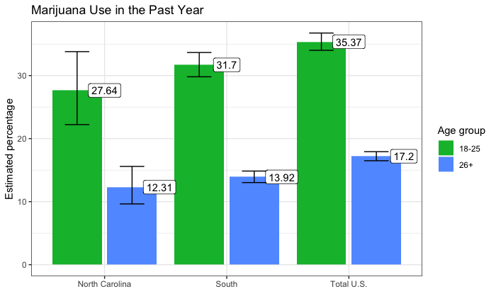

```r
# Selecting prevalence estimates that were significantly different from another
significant_data = subset(table_2, significant_diff == "1")

# Creating bar chart
ggplot(data = significant_data,
       mapping = aes(x = state, y = estimate, label = estimate, group = age_group)) +

  ggtitle("Marijuana Use in the Past Year") +

  ylab("Estimated percentage") +
  xlab("") +

  guides(fill = guide_legend(title = "Age group")) +

  geom_bar(aes(fill = age_group),
           stat = "identity",
           position = position_dodge2(preserve = "single")) +

  geom_label(data = subset(significant_data, age_group == "18-25")) +
  geom_label(data = subset(significant_data, age_group == "26+"),
             nudge_x = label_nudge) +

  geom_errorbar(aes(ymin = lower_CI, ymax = upper_CI),
                position = position_dodge(preserve = "single", width = 0.9),
                width = error_bar_width) +

  scale_fill_manual(values = c("#00BA38","#619CFF")) +

  theme_bw()
```

```r
# Creating tables of confidence intervals
kable(subset(significant_data, age_group == "18-25")[ , -c(2, 3, 6)],
      caption = "Confidence intervals for Table 2 (18 - 25 years old)",
      row.names = FALSE,
      col.names = col_names)
```

Confidence intervals for Table 2 (18 - 25 years old)

| State | Lower CI | Upper CI |
| --- | --- | --- |
| Total U.S. | 34.01 | 36.75 |
| South | 29.81 | 33.66 |
| North Carolina | 22.22 | 33.80 |

```r
kable(subset(significant_data, age_group == "26+")[ , -c(2, 3, 6)],
      caption = "Confidence intervals for Table 2 (26+ years old)",
      row.names = FALSE,
      col.names = col_names)
```

Confidence intervals for Table 2 (26+ years old)

| State | Lower CI | Upper CI |
| --- | --- | --- |
| Total U.S. | 16.49 | 17.93 |
| South | 13.03 | 14.85 |
| North Carolina | 9.64 | 15.59 |

In the 18 - 25 year old group, the estimate for the U.S. was significantly higher than those recorded for the South and NC.  
In the 26+ year old group, the estimate for the U.S. was significantly higher than those recorded for the South and NC.

### Table 3 Results (among people aged 12 or older)

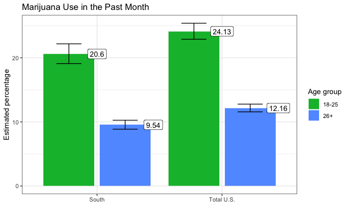

```r
# Selecting prevalence estimates that were significantly different from another
significant_data = subset(table_3, significant_diff == "1")

# Creating bar chart
ggplot(data = significant_data,
       mapping = aes(x = state, y = estimate, label = estimate, group = age_group)) +

  ggtitle("Marijuana Use in the Past Month") +

  ylab("Estimated percentage") +
  xlab("") +

  guides(fill = guide_legend(title = "Age group")) +

  geom_bar(aes(fill = age_group),
           stat = "identity",
           position = position_dodge2(preserve = "single")) +

  geom_label(data = subset(significant_data, age_group == "18-25")) +
  geom_label(data = subset(significant_data, age_group == "26+"),
             nudge_x = label_nudge) +

  geom_errorbar(aes(ymin = lower_CI, ymax = upper_CI),
                position = position_dodge(preserve = "single", width = 0.9),
                width = error_bar_width) +

  scale_fill_manual(values = c("#00BA38","#619CFF")) +

  theme_bw()
```

```r
# Creating tables of confidence intervals
kable(subset(significant_data, age_group == "18-25")[ , -c(2, 3, 6)],
      caption = "Confidence intervals for Table 3 (18 - 25 years old)",
      row.names = FALSE,
      col.names = col_names)
```

Confidence intervals for Table 3 (18 - 25 years old)

| State | Lower CI | Upper CI |
| --- | --- | --- |
| Total U.S. | 22.9 | 25.40 |
| South | 19.1 | 22.18 |

```r
kable(subset(significant_data, age_group == "26+")[ , -c(2, 3, 6)],
      caption = "Confidence intervals for Table 3 (26+ years old)",
      row.names = FALSE,
      col.names = col_names)
```

Confidence intervals for Table 3 (26+ years old)

| State | Lower CI | Upper CI |
| --- | --- | --- |
| Total U.S. | 11.57 | 12.77 |
| South | 8.86 | 10.26 |

In the 18 - 25 year old group, the estimate for the U.S. was significantly higher than that recorded for the South.  
In the 26+ year old group, the estimate for the U.S. was significantly higher than that recorded for the South.

### Table 4 Results (among people aged 12 or older)

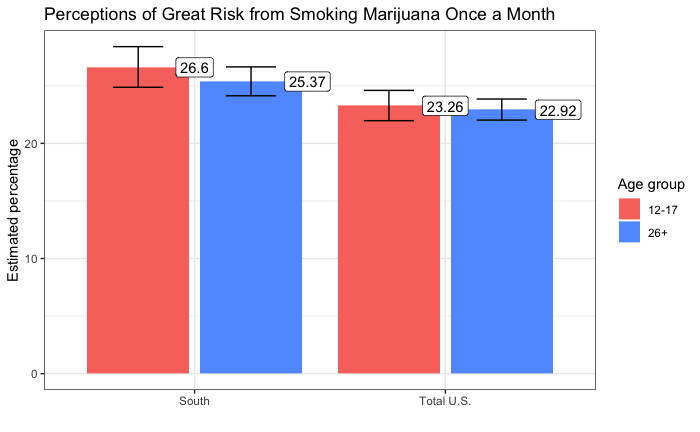

```r
# Selecting prevalence estimates that were significantly different from another
significant_data = subset(table_4, significant_diff == "1")

# Creating bar chart
ggplot(data = significant_data,
       mapping = aes(x = state, y = estimate, label = estimate, group = age_group)) +

  ggtitle("Perceptions of Great Risk from Smoking Marijuana Once a Month") +

  ylab("Estimated percentage") +
  xlab("") +

  guides(fill = guide_legend(title = "Age group")) +

  geom_bar(aes(fill = age_group),
           stat = "identity",
           position = position_dodge2(preserve = "single")) +

  geom_label(data = subset(significant_data, age_group == "12-17")) +
  geom_label(data = subset(significant_data, age_group == "26+"),
             nudge_x = label_nudge) +

  geom_errorbar(aes(ymin = lower_CI, ymax = upper_CI),
                position = position_dodge(preserve = "single", width = 0.9),
                width = error_bar_width) +

  scale_fill_manual(values = c("#F8766D","#619CFF")) +

  theme_bw()
```

```r
# Creating tables of confidence intervals
kable(subset(significant_data, age_group == "12-17")[ , -c(2, 3, 6)],
      caption = "Confidence intervals for Table 4 (12 - 17 years old)",
      row.names = FALSE,
      col.names = col_names)
```

Confidence intervals for Table 4 (12 - 17 years old)

| State | Lower CI | Upper CI |
| --- | --- | --- |
| Total U.S. | 21.97 | 24.6 |
| South | 24.87 | 28.4 |

```r
kable(subset(significant_data, age_group == "26+")[ , -c(2, 3, 6)],
      caption = "Confidence intervals for Table 4 (26+ years old)",
      row.names = FALSE,
      col.names = col_names)
```

Confidence intervals for Table 4 (26+ years old)

| State | Lower CI | Upper CI |
| --- | --- | --- |
| Total U.S. | 22.02 | 23.85 |
| South | 24.13 | 26.64 |

In the 12 - 17 year old group, the estimate for the South was significantly higher than that recorded for the U.S.  
In the 26+ year old group, the estimate for the South was significantly higher than that recorded for the U.S.

### Table 8 Results (among people aged 12 or older)

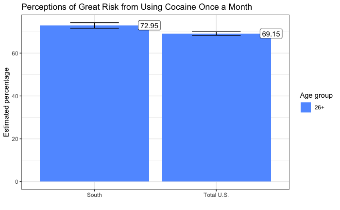

```r
# Selecting prevalence estimates that were significantly different from another
significant_data = subset(table_8, significant_diff == "1")

# Creating bar chart
ggplot(data = significant_data,
       mapping = aes(x = state, y = estimate, label = estimate)) +

  ggtitle("Perceptions of Great Risk from Using Cocaine Once a Month") +

  ylab("Estimated percentage") +
  xlab("") +

  guides(fill = guide_legend(title = "Age group")) +

  geom_bar(aes(fill = age_group),
           stat = "identity") +

  geom_label(nudge_x = label_nudge) +

  geom_errorbar(aes(ymin = lower_CI, ymax = upper_CI),
                width = error_bar_width) +

  scale_fill_manual(values = c("#619CFF")) +

  theme_bw()
```

```r
# Creating table of confidence intervals
kable(significant_data[ , -c(2, 3, 6)],
      caption = "Confidence intervals for Table 8 (26+ years old)",
      row.names = FALSE,
      col.names = col_names)
```

Confidence intervals for Table 8 (26+ years old)

| State | Lower CI | Upper CI |
| --- | --- | --- |
| Total U.S. | 68.30 | 69.99 |
| South | 71.65 | 74.22 |

In the 26+ year old group, the estimate for the South was significantly higher than that recorded for the U.S.

### Table 10 Results (among people aged 12 or older)

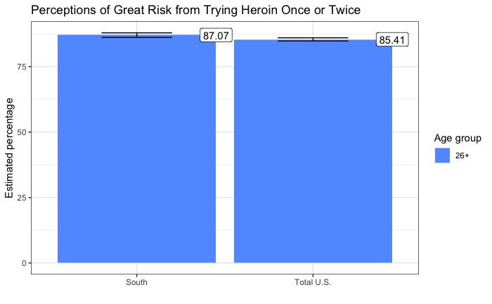

```r
# Selecting prevalence estimates that were significantly different from another
significant_data = subset(table_10, significant_diff == "1")

# Creating bar chart
ggplot(data = significant_data,
       mapping = aes(x = state, y = estimate, label = estimate)) +

  ggtitle("Perceptions of Great Risk from Trying Heroin Once or Twice") +

  ylab("Estimated percentage") +
  xlab("") +

  guides(fill = guide_legend(title = "Age group")) +

  geom_bar(aes(fill = age_group),
           stat = "identity") +

  geom_label(nudge_x = label_nudge) +

  geom_errorbar(aes(ymin = lower_CI, ymax = upper_CI),
                width = error_bar_width) +

  scale_fill_manual(values = c("#619CFF")) +

  theme_bw()
```

```r
# Creating table of confidence intervals
kable(significant_data[ , -c(2, 3, 6)],
      caption = "Confidence intervals for Table 10 (26+ years old)",
      row.names = FALSE,
      col.names = col_names)
```

Confidence intervals for Table 10 (26+ years old)

| State | Lower CI | Upper CI |
| --- | --- | --- |
| Total U.S. | 84.79 | 86.02 |
| South | 86.17 | 87.92 |

In the 26+ year old group, the estimate for the South was significantly higher than that recorded for the U.S.

### Table 17 Results

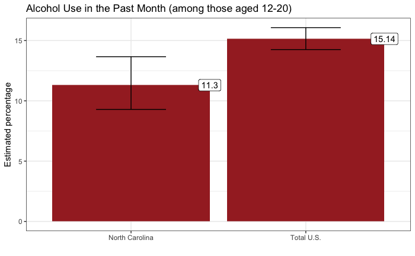

```r
# Selecting prevalence estimates that were significantly different from another
significant_data = subset(table_17, significant_diff == "1")

# Creating bar chart
ggplot(data = significant_data,
       mapping = aes(x = state, y = estimate, label = estimate)) +

  ggtitle("Alcohol Use in the Past Month (among those aged 12-20)") +

  ylab("Estimated percentage") +
  xlab("") +

  geom_bar(stat = "identity",
           fill = "brown") +

  geom_label(nudge_x = label_nudge) +

  geom_errorbar(aes(ymin = lower_CI, ymax = upper_CI),
                width = error_bar_width) +

  theme_bw()
```

```r
# Creating table of confidence intervals
kable(significant_data[ , -c(2, 3, 6)],
      caption = "Confidence intervals for Table 17",
      row.names = FALSE,
      col.names = col_names)
```

Confidence intervals for Table 17

| State | Lower CI | Upper CI |
| --- | --- | --- |
| Total U.S. | 14.25 | 16.07 |
| North Carolina | 9.29 | 13.66 |

Table 17 also records binge alcohol use, but no significant differences were found for that metric.  
The estimate for the U.S. was significantly higher than that of NC.

### Table 18 Results (among people aged 12 or older)

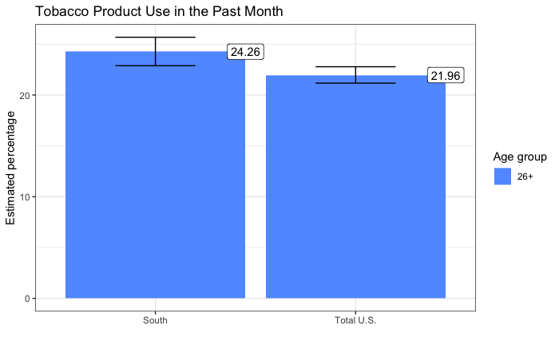

```r
# Selecting prevalence estimates that were significantly different from another
significant_data = subset(table_18, significant_diff == "1")

# Creating bar chart
ggplot(data = significant_data,
       mapping = aes(x = state, y = estimate, label = estimate)) +

  ggtitle("Tobacco Product Use in the Past Month") +

  ylab("Estimated percentage") +
  xlab("") +

  guides(fill = guide_legend(title = "Age group")) +

  geom_bar(aes(fill = age_group),
           stat = "identity") +

  geom_label(nudge_x = label_nudge) +

  geom_errorbar(aes(ymin = lower_CI, ymax = upper_CI),
                width = error_bar_width) +

  scale_fill_manual(values = c("#619CFF")) +

  theme_bw()
```

```r
# Creating table of confidence intervals
kable(significant_data[ , -c(2, 3, 6)],
      caption = "Confidence intervals for Table 18 (26+ years old)",
      row.names = FALSE,
      col.names = col_names)
```

Confidence intervals for Table 18 (26+ years old)

| State | Lower CI | Upper CI |
| --- | --- | --- |
| Total U.S. | 21.17 | 22.78 |
| South | 22.88 | 25.68 |

Tobacco products include cigarettes, smokeless tobacco (i.e. snuff, dip, chewing tobacco, or snus), cigars, or pipe tobacco.  
In the 26+ year old group, the estimate for the South was significantly higher than that recorded for the U.S.

## Summary

- In the 12 - 17 year old group:
  - The South ranked higher than the U.S. in perceptions of great risk from smoking marijuana once a month.
- In the 12 - 20 year old group:
  - The U.S. ranked higher than NC in alcohol use in the past month.
- In the 18 - 25 year old group:
  - The U.S. ranked higher than the South and NC in illicit drug use in the past month and marijuana use in the past year.
  - The U.S. ranked higher than the South in marijuana use in the past month.
- In the 26+ year old group:
  - The U.S. ranked higher than the South and NC in marijuana use in the past year.
  - The U.S. ranked higher than the South in illicit drug use in the past month and marijuana use in the past month.
  - The South ranked higher than the U.S. in tobacco product use in the past month and in the three following risk tables: perceptions of great risk from smoking marijuana once a month, using cocaine once a month, and trying heroin once or twice.

# Conclusion

Some key takeaways are:

- Other than tobacco product use in the past month (where the South ranked higher than the U.S. for those aged 26+), the U.S. ranked higher than the South or NC in all substance use tables where significant differences were found.
- The South ranked higher than the U.S. in all perceived risk tables where significant differences were found.
- In the 26+ year old group, relative to the U.S, the South’s higher perceived risk from smoking marijuana once a month inversely correlated with its lower percentages in marijuana use in the past month or year.
- No significant differences were found between the prevalence estimates of the South and those of NC.
- The 26+ year old group had the greatest number of significant differences, while the 12 - 17 and 12 - 20 year old groups had the least (note that only one source table uses the 12 - 20 year old group).